# Revisión

- ¿Debemos explorar las relaciones entre nuestras variables?

Sí y depende de eso podemos elegir el modelo * ¿Por qué usamos el paquete `edgeR`? Sirve para normalizar los datos Nos permite eliminar el composition bias

- ¿Por qué es importante el argumento `sort.by` en `topTable()`? queriamos preservar el orden original para que los renglones del objeto rse tengan el mismo orden de la tabla
- ¿Por qué es importante el argumento `coef` en `topTable()`? Es el coeficiente de interés lo que corresponde a model.matrix con la que creamos la matriz del diseño estadístico

Usemos los datos de http://research.libd.org/SPEAQeasy-example/bootcamp_intro

```r
speaqeasy_data <- file.path(tempdir(), "rse_speaqeasy.RData")
download.file("https://github.com/LieberInstitute/SPEAQeasy-example/blob/master/rse_speaqeasy.RData?raw=true", speaqeasy_data, mode = "wb")
library("SummarizedExperiment")
# cargamos los datos y con verbose R nos avisa cuales son los nombres de los objetos
load(speaqeasy_data, verbose = TRUE)
```

```
## Loading objects:
##   rse_gene
```

```r
rse_gene
```

```
## class: RangedSummarizedExperiment
## dim: 60609 40
## metadata(0):
## assays(1): counts
## rownames(60609): ENSG00000223972.5 ENSG00000227232.5 ...
##   ENSG00000210195.2 ENSG00000210196.2
## rowData names(10): Length gencodeID ... NumTx gencodeTx
## colnames(40): R13896_H7JKMBBXX R13903_HCTYLBBXX ... R15120_HFY2MBBXX
##   R15134_HFFGHBBXX
## colData names(67): SAMPLE_ID FQCbasicStats ... AgeDeath BrNum
```

```r
# isee o ggplot2, scater
colData(rse_gene)$names
```

```r
rse_gene$totalAssignedGene == rse_gene$mitoRate
```

```
##  [1] FALSE FALSE FALSE FALSE FALSE FALSE FALSE FALSE FALSE FALSE FALSE FALSE
## [13] FALSE FALSE FALSE FALSE FALSE FALSE FALSE FALSE FALSE FALSE FALSE FALSE
## [25] FALSE FALSE FALSE FALSE FALSE FALSE FALSE FALSE FALSE FALSE FALSE FALSE
## [37] FALSE FALSE FALSE FALSE
```

```r
rse_gene$PrimaryDx
```

```
##  [1] Bipolar Bipolar Bipolar Bipolar Control Control Control Control Control
## [10] Control Control Control Control Bipolar Bipolar Bipolar Control Control
## [19] Control Bipolar Bipolar Control Bipolar Bipolar Bipolar Bipolar Control
## [28] Control Control Bipolar Bipolar Bipolar Control Control Bipolar Bipolar
## [37] Bipolar Bipolar Control Control
## Levels: Bipolar Control Other
```

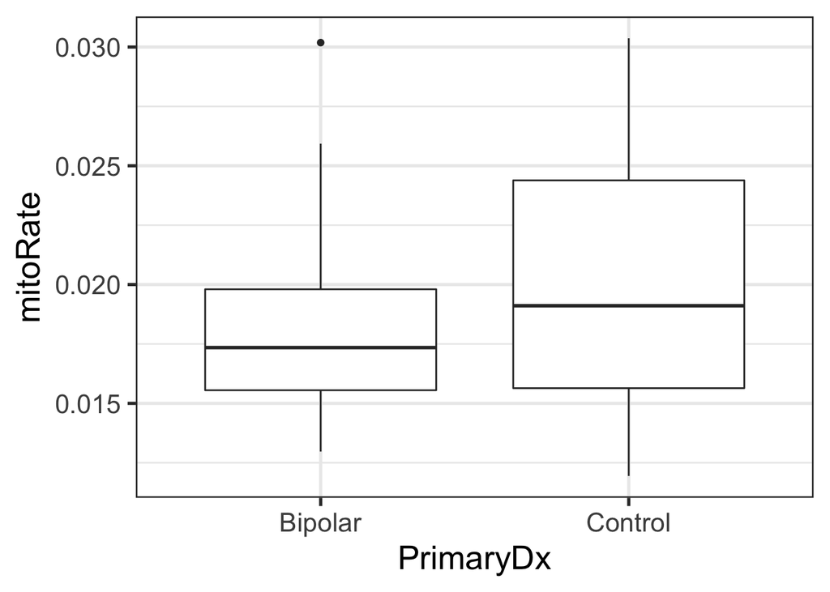

```r
library("ggplot2")
ggplot(as.data.frame(colData(rse_gene)), aes(y = mitoRate, x = PrimaryDx)) +
    geom_boxplot() +
    theme_bw(base_size = 20) +
    ylab("mitoRate") +
    xlab("PrimaryDx")
```

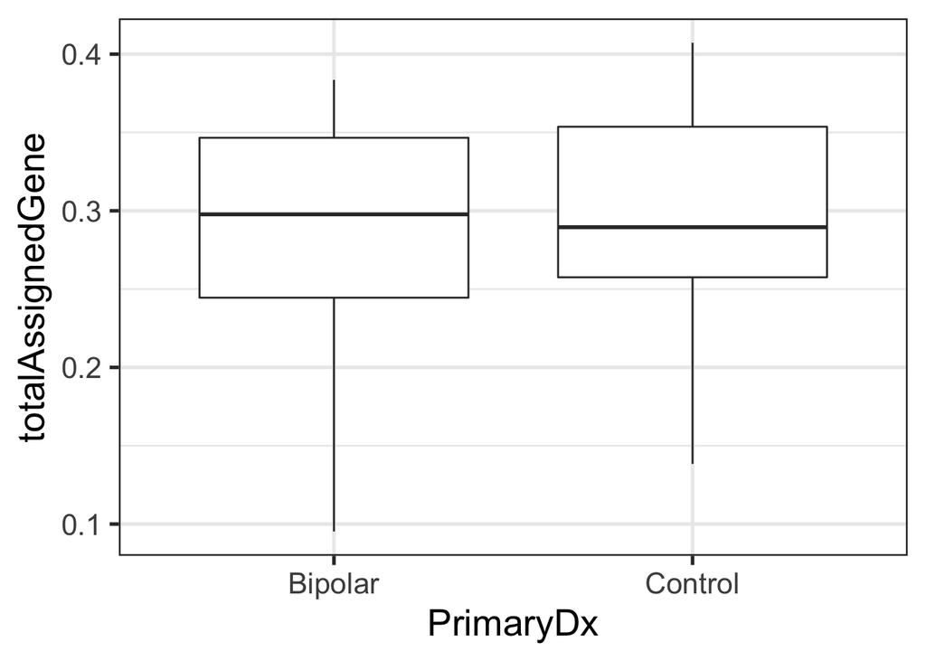

```r
ggplot(as.data.frame(colData(rse_gene)), aes(y = totalAssignedGene, x = PrimaryDx)) +
    geom_boxplot() +
    theme_bw(base_size = 20) +
    ylab("totalAssignedGene") +
    xlab("PrimaryDx")
```

- Grafica la expresión de *SNAP25* para cada grupo de diagnosis.

```r
# Es un gen marcador de neuronas, no debería haber diferencia ggplot2, scater o isee
```

```r
rse_gene
```

```
## class: RangedSummarizedExperiment
## dim: 60609 40
## metadata(0):
## assays(1): counts
## rownames(60609): ENSG00000223972.5 ENSG00000227232.5 ...
##   ENSG00000210195.2 ENSG00000210196.2
## rowData names(10): Length gencodeID ... NumTx gencodeTx
## colnames(40): R13896_H7JKMBBXX R13903_HCTYLBBXX ... R15120_HFY2MBBXX
##   R15134_HFFGHBBXX
## colData names(67): SAMPLE_ID FQCbasicStats ... AgeDeath BrNum
```

```r
rowData(rse_gene)$Symbol== "SNAP25"
```

[output not shown]

```r
index_snap<-match(c("SNAP25"), rowData(rse_gene)$Symbol)

rse_gene[index_snap]
```

```
## class: RangedSummarizedExperiment
## dim: 1 40
## metadata(0):
## assays(1): counts
## rownames(1): ENSG00000132639.12
## rowData names(10): Length gencodeID ... NumTx gencodeTx
## colnames(40): R13896_H7JKMBBXX R13903_HCTYLBBXX ... R15120_HFY2MBBXX
##   R15134_HFFGHBBXX
## colData names(67): SAMPLE_ID FQCbasicStats ... AgeDeath BrNum
```

```r
library("iSEE")
iSEE::iSEE(rse_gene[index_snap])
```

- Sugiere un modelo estadistico que podríamos usar en una análisis de expresión diferencial. Verifica que si sea un modelo *full rank*. ¿Cúal sería el o los coeficientes de interés? Si todas las columnas son linealmente independientes a las otras. Si no es full rank no se puede usar para el analisis de expresión diferencial

Utilizamos el modelo de expresión diferencial

```r
# explormodelmatrix

mod <- model.matrix(~ PrimaryDx + totalAssignedGene + mitoRate + numReads,
    data = colData(rse_gene)
)
colnames(mod)
```

```
## [1] "(Intercept)"       "PrimaryDxControl"  "PrimaryDxOther"
## [4] "totalAssignedGene" "mitoRate"          "numReads"
```

```r
library("edgeR") # BiocManager::install("edgeR", update = FALSE)
dge <- DGEList(
    counts = assay(rse_gene, "counts"),
    genes = rowData(rse_gene)
)
dge <- calcNormFactors(dge)
```

[output not shown]

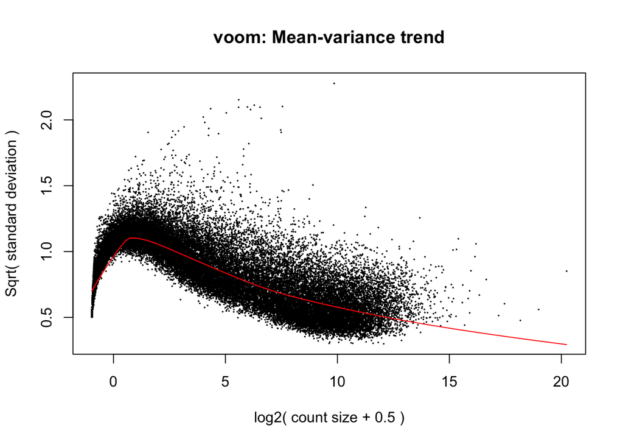

```r
library("limma")
vGene<- voom(dge,mod,plot=TRUE)
```

¿Quieres más datos? Tenemos muchos en LIBD incluyendo http://eqtl.brainseq.org/phase2/.

# spatialLIBD

> 🔥off the press! 👀 our [@biorxivpreprint](https://twitter.com/biorxivpreprint?ref_src=twsrc%5Etfw) on human 🧠brain [@LieberInstitute](https://twitter.com/LieberInstitute?ref_src=twsrc%5Etfw) spatial 🌌🔬transcriptomics data 🧬using Visium [@10xGenomics](https://twitter.com/10xGenomics?ref_src=twsrc%5Etfw)🎉[#spatialLIBD](https://twitter.com/hashtag/spatialLIBD?src=hash&ref_src=twsrc%5Etfw)  
> 🔍https://t.co/RTW0VscUKR  
> 👩🏾‍💻https://t.co/bsg04XKONr  
> 📚https://t.co/FJDOOzrAJ6  
> 📦https://t.co/Au5jwADGhYhttps://t.co/PiWEDN9q2N [pic.twitter.com/aWy0yLlR50](https://t.co/aWy0yLlR50)

> — 🇲🇽 Leonardo Collado-Torres (@lcolladotor) [February 29, 2020](https://twitter.com/lcolladotor/status/1233661576433061888?ref_src=twsrc%5Etfw)
- Artículo: https://www.nature.com/articles/s41593-020-00787-0
- Software: http://research.libd.org/spatialLIBD/
- Interfaz de shiny: http://spatial.libd.org/spatialLIBD/
- Pre-print sobre `SpatialExperiment` https://www.biorxiv.org/content/10.1101/2021.01.27.428431v1

> Are you working with spatial transcriptomics data such as Visium from [@10xGenomics](https://twitter.com/10xGenomics?ref_src=twsrc%5Etfw)? Then you'll be interested in [#SpatialExperiment](https://twitter.com/hashtag/SpatialExperiment?src=hash&ref_src=twsrc%5Etfw) 📦 led by [@drighelli](https://twitter.com/drighelli?ref_src=twsrc%5Etfw) [@lmwebr](https://twitter.com/lmwebr?ref_src=twsrc%5Etfw) [@CrowellHL](https://twitter.com/CrowellHL?ref_src=twsrc%5Etfw) with contributions by [@PardoBree](https://twitter.com/PardoBree?ref_src=twsrc%5Etfw) [@shazanfar](https://twitter.com/shazanfar?ref_src=twsrc%5Etfw) A Lun [@stephaniehicks](https://twitter.com/stephaniehicks?ref_src=twsrc%5Etfw) [@drisso1893](https://twitter.com/drisso1893?ref_src=twsrc%5Etfw) 🌟  
> 📜 https://t.co/r36qlakRJe [pic.twitter.com/cWIiwLFitV](https://t.co/cWIiwLFitV)

> — 🇲🇽 Leonardo Collado-Torres (@lcolladotor) [January 29, 2021](https://twitter.com/lcolladotor/status/1355208674856329218?ref_src=twsrc%5Etfw)

Brenda Pardo

https://twitter.com/PardoBree

> Today I gave my first talk at a congress in [#EuroBioc2020](https://twitter.com/hashtag/EuroBioc2020?src=hash&ref_src=twsrc%5Etfw) about our work on adapting the package [#spatialLIBD](https://twitter.com/hashtag/spatialLIBD?src=hash&ref_src=twsrc%5Etfw) to use VisiumExperiment objects. [pic.twitter.com/U23yE32RWM](https://t.co/U23yE32RWM)

> — Brenda Pardo (@PardoBree) [December 14, 2020](https://twitter.com/PardoBree/status/1338560370382942209?ref_src=twsrc%5Etfw)

## Comunidad

- https://twitter.com/miR_community
- https://twitter.com/R_LGBTQ
- https://twitter.com/conecta_R
- https://twitter.com/LatinR_Conf
- https://twitter.com/R4DScommunity
- https://twitter.com/RConsortium
- https://twitter.com/rweekly_org
- https://twitter.com/RLadiesGlobal
- https://twitter.com/RLadiesBmore
- https://twitter.com/search?q=%23RLadiesMX&src=typed_query

> The blog post about the First annual meeting of [#RLadiesMX](https://twitter.com/hashtag/RLadiesMX?src=hash&ref_src=twsrc%5Etfw) is ready!! All [#rladies](https://twitter.com/hashtag/rladies?src=hash&ref_src=twsrc%5Etfw) chapters in México met for the first time! 🤩 Spread the word and join this amazing community 💜https://t.co/evY4Tc18rw Thanks [@AnaBetty2304](https://twitter.com/AnaBetty2304?ref_src=twsrc%5Etfw) [@Averi_GG](https://twitter.com/Averi_GG?ref_src=twsrc%5Etfw) and [@josschavezf1](https://twitter.com/josschavezf1?ref_src=twsrc%5Etfw) for all your work!

> — RLadies Cuernavaca (@RLadiesCuerna) [January 30, 2021](https://twitter.com/RLadiesCuerna/status/1355655180751151107?ref_src=twsrc%5Etfw)
- https://twitter.com/Bioconductor
- https://twitter.com/rOpenSci
- https://twitter.com/LIBDrstats
- https://twitter.com/CDSBMexico

> ¡Chequen el nuevo blog post de Erick [@ErickCuevasF](https://twitter.com/ErickCuevasF?ref_src=twsrc%5Etfw)! 💯  
> Nos describe sus experiencias en [#BioC2020](https://twitter.com/hashtag/BioC2020?src=hash&ref_src=twsrc%5Etfw) y [#CDSB2020](https://twitter.com/hashtag/CDSB2020?src=hash&ref_src=twsrc%5Etfw)  
> Además estamos orgullxs de que Erick se unió a la Junta Directiva de la CDSB 🤩🎉  
> 👀 https://t.co/uGpgnqXvVM[#rstatsES](https://twitter.com/hashtag/rstatsES?src=hash&ref_src=twsrc%5Etfw) [pic.twitter.com/O2eIbk5YoZ](https://t.co/O2eIbk5YoZ)

> — ComunidadBioInfo (@CDSBMexico) [August 21, 2020](https://twitter.com/CDSBMexico/status/1296920807105540098?ref_src=twsrc%5Etfw)

## De ustedes

> [@fikandata](https://twitter.com/fikandata?ref_src=twsrc%5Etfw) [@MqElizabeth](https://twitter.com/MqElizabeth?ref_src=twsrc%5Etfw)  
> Looking for a solid and useful R 📦, we stumbled upon this  
> beauty 🤩 https://t.co/KR3twAxqRY  
> shoutouts to [@digitalwright](https://twitter.com/digitalwright?ref_src=twsrc%5Etfw) 👈!![@lcolladotor](https://twitter.com/lcolladotor?ref_src=twsrc%5Etfw) [@Bioconductor](https://twitter.com/Bioconductor?ref_src=twsrc%5Etfw)

> — Axel Zagal Norman (@NormanZagal) [February 24, 2021](https://twitter.com/NormanZagal/status/1364381133878611968?ref_src=twsrc%5Etfw)

> In today's lesson of bioinformatics course of undergraduate program in genomic sciences [@lcgunam](https://twitter.com/lcgunam?ref_src=twsrc%5Etfw) we created our first personal page using [@seankross](https://twitter.com/seankross?ref_src=twsrc%5Etfw)' postcards R package with [@lcolladotor](https://twitter.com/lcolladotor?ref_src=twsrc%5Etfw) as our instructor. [#rstats](https://twitter.com/hashtag/rstats?src=hash&ref_src=twsrc%5Etfw) https://t.co/sXUSietCZy

> — Angel Castillo (@angelcaztle13) [February 24, 2021](https://twitter.com/angelcaztle13/status/1364466027682140162?ref_src=twsrc%5Etfw)

> Wake up  
> Brew some [@tyulmalcafe](https://twitter.com/tyulmalcafe?ref_src=twsrc%5Etfw) beans  
> Attend [@lcolladotor](https://twitter.com/lcolladotor?ref_src=twsrc%5Etfw) amazing class on visualizing expression data using ISEE [@FedeBioinfo](https://twitter.com/FedeBioinfo?ref_src=twsrc%5Etfw) [@KevinRUE67](https://twitter.com/KevinRUE67?ref_src=twsrc%5Etfw) [@CSoneson](https://twitter.com/CSoneson?ref_src=twsrc%5Etfw)  
> Am I dreaming?  
> Nah! Mug is empty.

> — Alfredo Varela (@fikandata) [February 24, 2021](https://twitter.com/fikandata/status/1364669473634983941?ref_src=twsrc%5Etfw)

# Excelente seminario, muchas gracias !